# Academic Data Report

Miles Spencer

4/28/2022

## FACTORS AFFECTING PASSING A MATHEMATICS COURSE

When coming up with my final project for the BIOL 3100 class, I was interested in looking at how factors related to tutoring impacted the outcome of a students final grade in math courses. But due to the lengthy process required to get authorization to use data from the tutoring center, alongside access to the UVU student database, my only option was to get my hands on data from another source. Luckily, the instructor for the course, Dr. Geoffry Zahn, had a portion of the UVU database from 2013-2021 that had been made anonymous.

### A Whole Bunch of Data

The next job was going through the **117** variables in the course file and **79** variables in the student file to get the ones that I thought relevant to my analysis. This was a lengthy process, but I was able to get course data down to *15* variables and student data down to *8* variables. The data was now in an ordered state which less intimidating and more manageable for my computer to process.

The next thing I wanted to do was join the data together into one data set containing all the relevant data. This was down with three variables that were shared between the data set. Now each observation represented a math course taken by a student. The format of the current grade data was not quantifiable, so I added a variable that had the grade of “A” set to a value of 4.0, “A-” set to a value of 3.7, and so forth following how UVU calculates grade point average.

```
## Rows: 160,444
## Columns: 21
## $ student_warehouse_entity_uid <dbl> 415326, 416266, 416273, 416279, 430377, 4~
## $ academic_year                <dbl> 2013, 2013, 2013, 2013, 2013, 2013, 2013,~
## $ academic_period_desc         <chr> "2013 SPRING", "2013 SPRING", "2013 SPRIN~
## $ course_identification        <chr> "MAT0990", "MAT1010", "MATH1050", "MAT099~
## $ subject                      <chr> "MAT", "MAT", "MATH", "MAT", "MAT", "MATH~
## $ instr_warehouse_entity_uid   <dbl> 374312, 295751, 1199, 463035, 422716, 699~
## $ instruction_method           <chr> NA, "LEC", NA, NA, NA, "LEC", NA, NA, NA,~
## $ final_grade                  <chr> "A", "C", "W", "E", "UW", "A-", "E", "UW"~
## $ sub_academic_period_desc     <chr> "Full Term", "HS Semester", "Full Term", ~
## $ repeat_course_ind            <chr> NA, NA, NA, "I", "I", NA, NA, "I", NA, NA~
## $ course_credits               <dbl> 4, 4, 4, 4, 4, 3, 5, 4, 4, 3, 3, 3, 3, 4,~
## $ course_campus_desc           <chr> "Main Campus", "Main Campus", "Main Campu~
## $ schedule_type_desc           <chr> "Face to Face", "Face to Face", "Face to ~
## $ residency                    <chr> "N", "R", "R", "N", "R", "R", "R", "R", "~
## $ credits_earned               <dbl> 4, 4, 0, 0, 0, 3, 0, 0, 0, 3, 3, 0, 3, 0,~
## $ age                          <dbl> 19, NA, 54, 23, 34, 18, 38, 18, 21, 18, 1~
## $ gender                       <chr> "F", NA, "F", "M", "F", "M", "M", "M", "F~
## $ primary_ethnicity_desc       <chr> "Hispanic/Latino/Latina", NA, "White", "W~
## $ term_cumulative_gpa          <dbl> 2.333333, NA, 0.000000, 1.200000, 0.00000~
## $ state_residency              <chr> "N", NA, "R", "N", "R", "R", "R", "R", "R~
## $ grade_score                  <dbl> 4.0, 2.0, 0.0, 0.0, 0.0, 3.7, 0.0, 0.0, 0~
```

### Visualizing the Data

Now that the data was in a workable format, I wanted to start looking at the effects different variables had on whether a student passes or fails a course. The pass/fail variable is based on whether a student received any credit from the course and not whether the grade received was sufficient to fulfill any requirements.

Looking at this graph, it looks like the proportion of students who failed their math class went down in 2020 and 2021 went down. These were the years when COVID-19 was affecting everything, so it is possible that teachers were more lenient during COVID and more likely to pass their students. I can look at this in a model, using academic year as an explanatory variable.

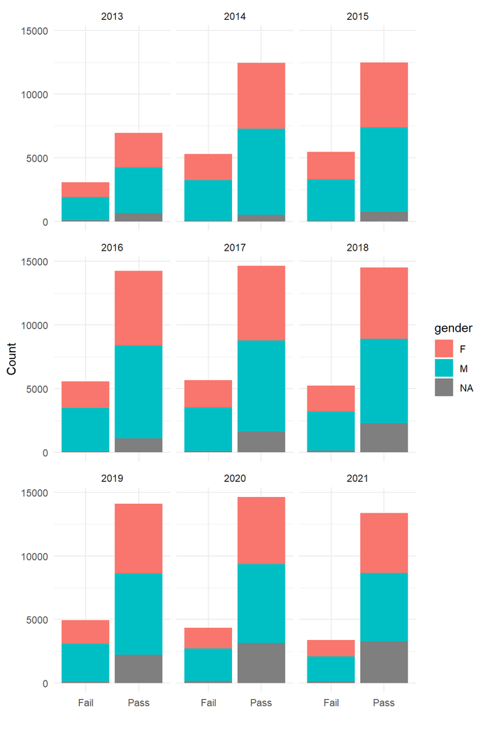

When looking at pass and fail proportions by ethnicity, it appears that the ethnicity of the student may be a predictor on whether the student passes or fails.

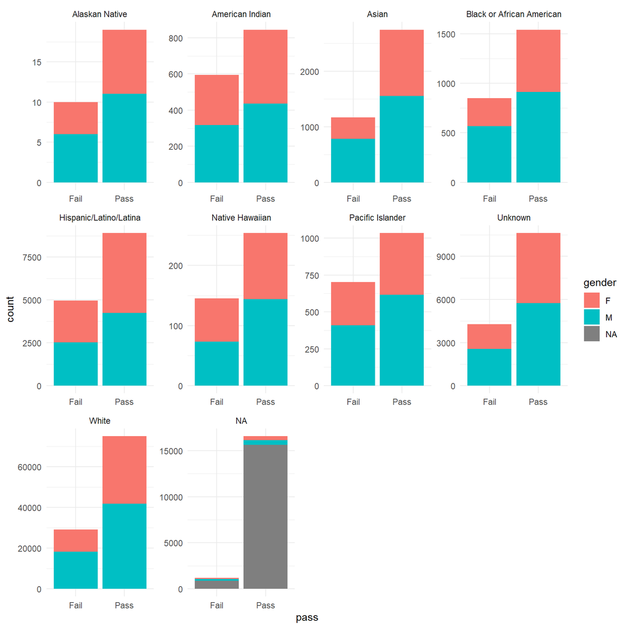

### Running Models

I am going to ignore the ethnicity of the students when creating my models. The variables I do want to take into account are academic year, gender, age, and course ID.

```
## Linear mixed model fit by REML. t-tests use Satterthwaite's method [
## lmerModLmerTest]
## Formula: grade_score ~ academic_year + gender + age + (1 | subject)
##    Data: .
##
## REML criterion at convergence: 526543
##
## Scaled residuals:
##     Min      1Q  Median      3Q     Max
## -1.7112 -1.2089  0.1870  0.9069  1.6266
##
## Random effects:
##  Groups   Name        Variance Std.Dev.
##  subject  (Intercept) 0.05226  0.2286
##  Residual             2.27103  1.5070
## Number of obs: 143925, groups:  subject, 3
##
## Fixed effects:
##                 Estimate Std. Error         df t value Pr(>|t|)
## (Intercept)    4.701e+01  3.454e+00  1.196e+05   13.61   <2e-16 ***
## academic_year -2.209e-02  1.709e-03  1.435e+05  -12.92   <2e-16 ***
## genderM       -1.773e-01  8.057e-03  1.439e+05  -22.01   <2e-16 ***
## age           -8.137e-03  6.478e-04  1.439e+05  -12.56   <2e-16 ***
## ---
## Signif. codes:  0 '***' 0.001 '**' 0.01 '*' 0.05 '.' 0.1 ' ' 1
##
## Correlation of Fixed Effects:
##             (Intr) acdmc_ gendrM
## academic_yr -0.999
## genderM     -0.014  0.013
## age         -0.153  0.149 -0.058
```

The first model is a linear mixed-effect model. It is set up to predict the grade score with age, gender, and academic year as fixed effects, but then uses subject as a random effect.

```
## Linear mixed model fit by REML. t-tests use Satterthwaite's method [
## lmerModLmerTest]
## Formula:
## grade_score ~ academic_year + gender * age + (1 | subject/course_identification)
##    Data: .
##
## REML criterion at convergence: 506597.6
##
## Scaled residuals:
##     Min      1Q  Median      3Q     Max
## -2.6246 -0.8624  0.1015  0.8423  1.8599
##
## Random effects:
##  Groups                        Name        Variance Std.Dev.
##  course_identification:subject (Intercept) 0.45165  0.6721
##  subject                       (Intercept) 0.03102  0.1761
##  Residual                                  1.97263  1.4045
## Number of obs: 143925, groups:  course_identification:subject, 95; subject, 3
##
## Fixed effects:
##                 Estimate Std. Error         df t value Pr(>|t|)
## (Intercept)   -1.303e+01  3.625e+00  1.110e+05  -3.595 0.000325 ***
## academic_year  7.737e-03  1.794e-03  1.437e+05   4.313 1.61e-05 ***
## genderM        1.672e-01  2.935e-02  1.439e+05   5.694 1.24e-08 ***
## age           -2.451e-03  8.041e-04  1.439e+05  -3.048 0.002304 **
## genderM:age   -1.267e-02  1.209e-03  1.439e+05 -10.484  < 2e-16 ***
## ---
## Signif. codes:  0 '***' 0.001 '**' 0.01 '*' 0.05 '.' 0.1 ' ' 1
##
## Correlation of Fixed Effects:
##             (Intr) acdmc_ gendrM age
## academic_yr -0.999
## genderM      0.024 -0.027
## age         -0.098  0.092  0.612
## genderM:age -0.030  0.034 -0.964 -0.648
```

The second model is very similar to the first model, but the course ID is nested inside the subject. This is done because each course ID is specific to a subject and needs to be taken into account in our model for random effects. Also included in this model is the interaction effect of age and gender.

```
## # Comparison of Model Performance Indices
##
## Name |           Model |       AIC |      AICc |       BIC | R2 (cond.) | R2 (marg.) |   ICC |  RMSE | Sigma
## ------------------------------------------------------------------------------------------------------------
## mod1 | lmerModLmerTest | 5.265e+05 | 5.265e+05 | 5.266e+05 |      0.028 |      0.005 | 0.022 | 1.507 | 1.507
## mod2 | lmerModLmerTest | 5.066e+05 | 5.066e+05 | 5.066e+05 |      0.200 |      0.004 | 0.197 | 1.404 | 1.405
```

When looking at the comparison of the two models we are mainly interested in the R2 (marg.) and R2 (cond.) columns. The R2 values are measurements representing the proportion of the change in the grade score that’s explained by an my explanatory variables. The marginal R2 is the proportion of variation explained by the fixed effects and the conditional R2 is the proportion of variation as explained by the random effects. In this case, the amount of change in the grade score is explained very little by age, gender, and academic year. A larger portion of that change can be explained by the course the student is taking. This is an ideal outcome as we would hope not to see a students grade being affected by their gender or age. But it is interesting that the grade wasn’t affected by whether or not a student took their math class during a COVID-19 semester.

There is a lot of student data. As I mentioned in the introduction I would like to merge this data with the queue data from the Math Tutoring lab. With this I could see the impact that going to the tutoring lab and how many questions asked by the student has on the grade of a student.

There is also a lot of data that can be related back to the tutor allowing them to see the impact they have had on the students they tutor. It would be insightful overall to see which demographics use the lab enabling more directed marketing to under represented groups. I would also like to get permission to use the tutors data and demographics to see what the effects of tutoring has on their grades and performance in school.